# Wikipedia Word Embeddings with LSI

by: Eric S. Téllez

This demonstration shows how to use **Latent Semantic Indexing (LSI)** to generate dense word embeddings from Spanish and English Wikipedia, and how to use those embeddings for synonym search, arithmetic analogies, and UMAP visualisations.

Embeddings are generated with [`TextSearch.jl`](https://github.com/sadit/TextSearch.jl) from Wikipedia’s introductory corpus (the first 3 paragraphs per article). The vocabulary profile and global TF-IDF weights were trained on the full corpus (~14M paragraphs in ES, ~46M in EN), but the SVD is computed on the introductory subset—giving more weight to the definitional content of each article.

> **Note**: This demo requires having run `generate_wiki_embeddings.jl` to produce the embedding files in `demos/data/`.

```julia
using SimilaritySearch, SimSearchManifoldLearning
using TextSearch, TextSearch.LSI
using Plots, StatsBase, LinearAlgebra, Markdown, Random, Printf, JSON3
```

## Loading the embeddings

The embeddings are stored in a GloVe-like text format: one line per token, with the token followed by whitespace-separated vector components.

```julia
"""
Loads embeddings in GloVe text format.
Returns (matrix Float16 dim×n, vocab Vector{String}).
We use Float16 to reduce memory usage; distance functions convert to Float32 dynamically during computation.
"""
function load_glove_format(path::String; dtype=Float16, max_words=100_000)
    @info "Loading embeddings from $path (max $max_words words)"
    lines = readlines(path)
    n     = min(length(lines), max_words)
    dim   = length(split(lines[1])) - 1
    M     = Matrix{dtype}(undef, dim, n)
    vocab = Vector{String}(undef, n)
    for i in 1:n
        parts    = split(lines[i])
        vocab[i] = parts[1]
        for (j, v) in enumerate(@view parts[2:end])
            M[j, i] = parse(Float32, v)
        end
    end
    M, vocab
end

# Load Spanish embeddings (top 100k tokens)
emb_es, vocab_es = load_glove_format(joinpath(@__DIR__, "data", "wiki-es-lsi.txt"); max_words=100_000)

# Inverse mapping: token → index
vocab2id_es = Dict(w => i for (i, w) in enumerate(vocab_es))

@info "ES: $(length(vocab_es)) tokens, dim=$(size(emb_es, 1))"
```

```julia
# Load English embeddings (top 100k tokens)
emb_en, vocab_en = load_glove_format(joinpath(@__DIR__, "data", "wiki-en-lsi.txt"); max_words=100_000)
vocab2id_en = Dict(w => i for (i, w) in enumerate(vocab_en))
@info "EN: $(length(vocab_en)) tokens, dim=$(size(emb_en, 1))"
```

## Building the search index

We use `SearchGraph` with normalized cosine distance to perform fast approximate nearest neighbor search. Since all LSI vectors are unit-normalized ($\|v\|_2 = 1$), `Dist.NormCosine()` computes cosine distance without recalculating vector norms.

```julia
dist = Dist.NormCosine()

# Spanish index
db_es  = MatrixDatabase(emb_es)
G_es   = SearchGraph(dist, db_es)
ctx_es = SearchGraphContext(hyperparameters_callback=OptimizeParameters(MinRecall(0.99)))
index!(G_es, ctx_es)
optimize_index!(G_es, ctx_es, MinRecall(0.9))

# English index
db_en  = MatrixDatabase(emb_en)
G_en   = SearchGraph(dist, db_en)
ctx_en = SearchGraphContext(hyperparameters_callback=OptimizeParameters(MinRecall(0.99)))
index!(G_en, ctx_en)
optimize_index!(G_en, ctx_en, MinRecall(0.9))
```

## Synonym and related word search

Nearest neighbors in the LSI vector space identify semantically related words and synonyms:

```julia
function search_similar(G, ctx, vocab, vocab2id, word::String, k::Int=10)
    haskey(vocab2id, word) || return Markdown.parse("> ⚠️ Word '$word' not found in vocabulary")
    qid = vocab2id[word]
    res = knnqueue(ctx, k)
    search(G, ctx, G[qid], res)

    L = [
        """## Similar to _$(word)_""",
        """| # | Token | Cosine distance |""",
        """|---|-------|-----------------|"""
    ]
    for (j, p) in enumerate(IdDistView(res))
        w = vocab[p.id]
        push!(L, """| $j | **$w** | $(@sprintf "%.4f" p.dist) |""")
    end
    Markdown.parse(join(L, "\n"))
end

# Spanish examples
for word in ["física", "historia", "computación", "música", "planeta"]
    search_similar(G_es, ctx_es, vocab_es, vocab2id_es, word, 8) |> display
end
```

Similar to *física*

| # | Token | Cosine distance |
| --- | --- | --- |
| 1 | **física** | 0.0020 |
| 2 | **matemática** | 0.1357 |
| 3 | **teórica** | 0.1538 |
| 4 | **fisiología** | 0.1597 |
| 5 | **patología** | 0.1611 |
| 6 | **matemáticas** | 0.1699 |
| 7 | **biología** | 0.1758 |
| 8 | **farmacología** | 0.1777 |

Similar to *historia*

| # | Token | Cosine distance |
| --- | --- | --- |
| 1 | **historia** | 0.0005 |
| 2 | **contada** | 0.1440 |
| 3 | **mentalidades** | 0.2031 |
| 4 | **relatada** | 0.2539 |
| 5 | **narra** | 0.2603 |
| 6 | **providencialista** | 0.2622 |
| 7 | **relata** | 0.2676 |
| 8 | **Relata** | 0.2939 |

Similar to *computación*

| # | Token | Cosine distance |
| --- | --- | --- |
| 1 | **computación** | 0.0005 |
| 2 | **computacional** | 0.0454 |
| 3 | **informática** | 0.0479 |
| 4 | **computacionales** | 0.0630 |
| 5 | **informáticas** | 0.0903 |
| 6 | **optimización** | 0.1064 |
| 7 | **informáticos** | 0.1128 |
| 8 | **Procesamiento** | 0.1196 |

Similar to *música*

| # | Token | Cosine distance |
| --- | --- | --- |
| 1 | **música** | 0.0020 |
| 2 | **folclórica** | 0.0254 |
| 3 | **electroacústica** | 0.0293 |
| 4 | **músicas** | 0.0371 |
| 5 | **sacra** | 0.0396 |
| 6 | **incidental** | 0.0503 |
| 7 | **techno** | 0.0508 |
| 8 | **electrónica** | 0.0586 |

Similar to *planeta*

| # | Token | Cosine distance |
| --- | --- | --- |
| 1 | **planeta** | 0.0020 |
| 2 | **b** | 0.0122 |
| 3 | **sonda** | 0.0132 |
| 4 | **planetas** | 0.0142 |
| 5 | **extrasolar** | 0.0156 |
| 6 | **planetario** | 0.0161 |
| 7 | **tránsito** | 0.0166 |
| 8 | **astronómico** | 0.0171 |

```julia
# English examples
for word in ["physics", "history", "computer", "music", "planet"]
    search_similar(G_en, ctx_en, vocab_en, vocab2id_en, word, 8) |> display
end
```

Similar to *physics*

| # | Token | Cosine distance |
| --- | --- | --- |
| 1 | **physics** | 0.0000 |
| 2 | **chemistry** | 0.0249 |
| 3 | **biophysics** | 0.0503 |
| 4 | **astrophysics** | 0.0610 |
| 5 | **biochemistry** | 0.0645 |
| 6 | **geophysics** | 0.0684 |
| 7 | **biology** | 0.0723 |
| 8 | **microbiology** | 0.0835 |

Similar to *history*

| # | Token | Cosine distance |
| --- | --- | --- |
| 1 | **history** | 0.0015 |
| 2 | **details** | 0.0645 |
| 3 | **Pomerania** | 0.0674 |
| 4 | **see** | 0.0742 |
| 5 | **Postage** | 0.1196 |
| 6 | **region** | 0.1440 |
| 7 | **mentalities** | 0.1841 |
| 8 | **Wolgast** | 0.1948 |

Similar to *computer*

| # | Token | Cosine distance |
| --- | --- | --- |
| 1 | **computer** | 0.0010 |
| 2 | **computing** | 0.0654 |
| 3 | **simulations** | 0.0820 |
| 4 | **haptic** | 0.0889 |
| 5 | **optimization** | 0.0923 |
| 6 | **visualization** | 0.0923 |
| 7 | **robotics** | 0.0942 |
| 8 | **Adaptive** | 0.0947 |

Similar to *music*

| # | Token | Cosine distance |
| --- | --- | --- |
| 1 | **music** | 0.0039 |
| 2 | **electroacoustic** | 0.0483 |
| 3 | **incidental** | 0.0830 |
| 4 | **musics** | 0.0908 |
| 5 | **composes** | 0.0918 |
| 6 | **ethnomusicology** | 0.0962 |
| 7 | **choral** | 0.0967 |
| 8 | **polyphony** | 0.1055 |

Similar to *planet*

| # | Token | Cosine distance |
| --- | --- | --- |
| 1 | **planet** | 0.0000 |
| 2 | **planets** | 0.1831 |
| 3 | **moons** | 0.2192 |
| 4 | **interstellar** | 0.2251 |
| 5 | **Pluto** | 0.2319 |
| 6 | **cometary** | 0.2451 |
| 7 | **astrometry** | 0.2495 |
| 8 | **orbiting** | 0.2500 |

## Query expansion and synonym network

The LSI embeddings allow precomputing a **query expansion network**: for each token, its $k$ nearest neighbors in semantic space form an expansion set.

```julia
# Load pre-computed query expansion network
qexp_obj = JSON3.read(read(joinpath(@__DIR__, "data", "wiki-es-qexp.json"), String))
qexp_es  = qexp_obj.query_expansion

function show_expansion(qexp, word)
    sym = Symbol(word)
    haskey(qexp, sym) || return Markdown.parse("> ⚠️ '$word' not found in expansion network")
    neighbors = qexp[sym]
    isempty(neighbors) && return Markdown.parse("> '$word' has no expansion (high-frequency token)")
    Markdown.parse("""
    **$word** → $(join(["_$(v)_" for v in neighbors], ", "))
    """)
end

for p in ["ciencia", "guerra", "amor", "tecnología", "ciudad", "arte", "economía"]
    show_expansion(qexp_es, p) |> display
end
```

**ciencia** → *ficción*, *especulativa*, *fantasía*, *postciberpunk*, *Asimov*, *fandom*, *fantástica*, *distópica*

**guerra** → *bando*, *Thanagarianos*, *lucharon*, *combatieron*, *bélico*, *conflicto*, *luchó*, *librada*

**amor** → *amar*, *amorosa*, *sueños*, *Kāmadeva*, *soledad*, *amorosas*, *triste*, *loca*

**tecnología** → *tecnologías*, *tecnológicas*, *tecnológicos*, *informáticas*, *automatización*, *tecnológica*, *desarrollo*, *robótica*

**ciudad** → *Algenrodt*, *Resurgam*, *Caleo*, *אֶת*, *Mikros*, *Bulero*, *Mahrouk*, *Ftouh*

**arte** → *contemporáneo*, *exponer*, *exposiciones*, *invisual*, *Arte*, *exposición*, *pictóricas*, *coleccionismo*

**economía** → *económicas*, *económica*, *económico*, *macroeconómico*, *macroeconomía*, *economistas*, *productivos*, *economías*

## Do arithmetic analogies work?

Analogies of the form *“king is to man as queen is to woman”* are well known in word2vec models. In LSI, the semantic space is linear and derived from document-level co-occurrence. Linear analogy arithmetic works when concepts share similar document distributions:

$$\vec{v}_{\text{target}} \approx \vec{v}_a - \vec{v}_b + \vec{v}_d \quad \text{where } a:b :: c:d$$

```julia
function analogy(G, ctx, vocab, vocab2id, a, b, d, k=10)
    for w in (a, b, d)
        haskey(vocab2id, w) || return Markdown.parse("> ⚠️ Word '$w' not found in vocabulary")
    end
    va = Float32.(G[vocab2id[a]])
    vb = Float32.(G[vocab2id[b]])
    vd = Float32.(G[vocab2id[d]])
    vc = va - vb + vd
    normalize!(vc)

    res = knnqueue(ctx, k + 3)  # request extra candidates to filter out inputs
    search(G, ctx, Float16.(vc), res)

    exclude = Set([a, b, d])
    L = [
        """### Analogy: _$(a)_ is to _$(b)_ as _?_ is to _$(d)_""",
        """| # | Token | Distance |""",
        """|---|-------|----------|"""
    ]
    j = 0
    for p in IdDistView(res)
        w = vocab[p.id]
        w in exclude && continue
        j += 1
        j > k && break
        push!(L, """| $j | **$w** | $(@sprintf "%.4f" p.dist) |""")
    end
    Markdown.parse(join(L, "\n"))
end

# Classic analogies in Spanish
analogy(G_es, ctx_es, vocab_es, vocab2id_es, "rey", "hombre", "mujer") |> display
analogy(G_es, ctx_es, vocab_es, vocab2id_es, "París", "Francia", "España") |> display
analogy(G_es, ctx_es, vocab_es, vocab2id_es, "Madrid", "España", "Francia") |> display
analogy(G_es, ctx_es, vocab_es, vocab2id_es, "perro", "animal", "planta") |> display
```

Analogy: *rey* is to *hombre* as *?* is to *mujer*

| # | Token | Distance |
| --- | --- | --- |
| 1 | **consorte** | 0.1914 |
| 2 | **reina** | 0.2124 |
| 3 | **III** | 0.2197 |
| 4 | **IV** | 0.2231 |
| 5 | **II** | 0.2271 |
| 6 | **duque** | 0.2314 |
| 7 | **conde** | 0.2319 |
| 8 | **regente** | 0.2349 |
| 9 | **Hohenstaufen** | 0.2402 |
| 10 | **Balduino** | 0.2422 |

Analogy: *París* is to *Francia* as *?* is to *España*

| # | Token | Distance |
| --- | --- | --- |
| 1 | **Gourmont** | 0.4688 |
| 2 | **Carpeaux** | 0.4888 |
| 3 | **Théodore** | 0.5059 |
| 4 | **Corot** | 0.5068 |
| 5 | **Gleizes** | 0.5122 |
| 6 | **Bichat** | 0.5127 |
| 7 | **Puvis** | 0.5132 |
| 8 | **Lévy** | 0.5146 |
| 9 | **Musset** | 0.5249 |
| 10 | **simbolista** | 0.5298 |

Analogy: *Madrid* is to *España* as *?* is to *Francia*

| # | Token | Distance |
| --- | --- | --- |
| 1 | **Dykinson** | 0.4155 |
| 2 | **madrid** | 0.4385 |
| 3 | **Humanes** | 0.4497 |
| 4 | **Torrelodones** | 0.4561 |
| 5 | **Carmena** | 0.4663 |
| 6 | **comisionada** | 0.4702 |
| 7 | **Griñón** | 0.4727 |
| 8 | **Leguina** | 0.4756 |
| 9 | **RUBIO** | 0.4795 |
| 10 | **BESCAM** | 0.4810 |

Analogy: *perro* is to *animal* as *?* is to *planta*

| # | Token | Distance |
| --- | --- | --- |
| 1 | **disfraza** | 0.6113 |
| 2 | **soborna** | 0.6152 |
| 3 | **atormentado** | 0.6211 |
| 4 | **enamora** | 0.6230 |
| 5 | **Trama** | 0.6255 |
| 6 | **Argumento** | 0.6260 |
| 7 | **novia** | 0.6270 |
| 8 | **roba** | 0.6270 |
| 9 | **chica** | 0.6309 |
| 10 | **obsesiona** | 0.6309 |

```julia
# Analogies in English
analogy(G_en, ctx_en, vocab_en, vocab2id_en, "king", "man", "woman") |> display
analogy(G_en, ctx_en, vocab_en, vocab2id_en, "Paris", "France", "Spain") |> display
analogy(G_en, ctx_en, vocab_en, vocab2id_en, "Madrid", "Spain", "France") |> display
```

Analogy: *king* is to *man* as *?* is to *woman*

| # | Token | Distance |
| --- | --- | --- |
| 1 | **regnant** | 0.1680 |
| 2 | **consort** | 0.1709 |
| 3 | **queen** | 0.1860 |
| 4 | **regent** | 0.1948 |
| 5 | **princess** | 0.2129 |
| 6 | **dowager** | 0.2144 |
| 7 | **throne** | 0.2280 |
| 8 | **Amalaric** | 0.2363 |
| 9 | **Laodice** | 0.2378 |
| 10 | **duchess** | 0.2402 |

Analogy: *Paris* is to *France* as *?* is to *Spain*

| # | Token | Distance |
| --- | --- | --- |
| 1 | **Ribera** | 0.3403 |
| 2 | **Carles** | 0.3730 |
| 3 | **Seville** | 0.3735 |
| 4 | **Pujol** | 0.3740 |
| 5 | **Valladolid** | 0.3750 |
| 6 | **Zaragoza** | 0.3755 |
| 7 | **Aragonese** | 0.3760 |
| 8 | **Cervera** | 0.3809 |
| 9 | **Catalonia** | 0.3848 |
| 10 | **Vallès** | 0.3867 |

Analogy: *Madrid* is to *Spain* as *?* is to *France*

| # | Token | Distance |
| --- | --- | --- |
| 1 | **Belfort** | 0.1543 |
| 2 | **Hauts** | 0.1602 |
| 3 | **Essonne** | 0.1602 |
| 4 | **Oise** | 0.1709 |
| 5 | **Aisne** | 0.1758 |
| 6 | **Calais** | 0.1787 |
| 7 | **Provence** | 0.1904 |
| 8 | **Pas** | 0.1914 |
| 9 | **Marne** | 0.1934 |
| 10 | **Île** | 0.1938 |

## UMAP visualization

We project a sample of the most frequent vocabulary tokens into 2D using UMAP, using `SearchGraph` for the kNN neighborhood graph. We color the points using a 3D UMAP embedding normalized to RGB channels.

```julia
# Sample the most frequent vocabulary tokens for visualization
sample_size = min(15_000, length(vocab_es))
sample_idx  = 1:sample_size

db_sample  = SubDatabase(db_es, collect(sample_idx))
G_sample   = SearchGraph(dist, db_sample)
ctx_sample = SearchGraphContext(hyperparameters_callback=OptimizeParameters(MinRecall(0.95)))
index!(G_sample, ctx_sample)

e2, e3 = let k=15, n_epochs=75, neg_sample_rate=3, tol=1e-3, min_dist=0.3f0,
              layout=SpectralLayout()
    @time "UMAP 2D" U2 = fit(UMAP, G_sample; k, neg_sample_rate, layout, n_epochs, tol, min_dist)
    @time "UMAP 3D" U3 = fit(U2, 3; neg_sample_rate, n_epochs, tol)
    @time "predict 2D" e2 = clamp.(predict(U2), -10f0, 10f0)
    @time "predict 3D" e3 = clamp.(predict(U3), -10f0, 10f0)
    e2, e3
end
```

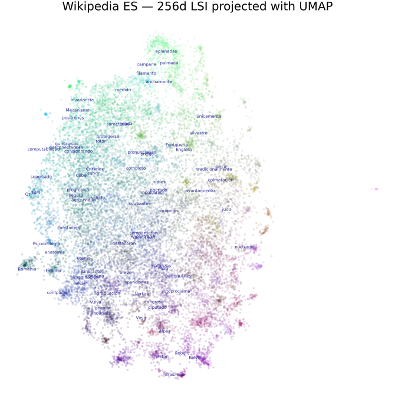

```julia
function normcolors(V)
    mn, mx = extrema(V)
    @. V = clamp((V - mn) / (mx - mn), 0, 1)
end

normcolors(@view e3[1, :])
normcolors(@view e3[2, :])
normcolors(@view e3[3, :])

C = [RGB(c[1], c[2], c[3]) for c in eachcol(e3)]
X, Y = view(e2, 1, :), view(e2, 2, :)

scatter(X, Y; color=C, fmt=:png, alpha=0.15, size=(700, 700),
        ma=0.2, ms=2, msw=0, label="",
        yticks=nothing, xticks=nothing, xaxis=false, yaxis=false,
        title="Wikipedia ES — 256d LSI projected with UMAP")

# Annotate ~80 random tokens
for _ in 1:80
    j = rand(1:sample_size)
    annotate!(X[j], Y[j], text(vocab_es[sample_idx[j]], :blue, :right, 5, "sans-serif"))
end
plot!()
```

## Concluding remarks

This demonstration shows how LSI embeddings derived from Wikipedia capture **semantic structure**: words associated through document co-occurrence naturally cluster in vector space.

## Environment and dependencies

```
Julia Version 1.12.7
Commit 6d172b025e4 (2026-08-15 08:05 UTC)
Build Info:
  Official https://julialang.org release
Platform Info:
  OS: Linux (x86_64-linux-gnu)
  CPU: 64 × Intel(R) Xeon(R) Silver 4216 CPU @ 2.10GHz
  WORD_SIZE: 64
  LLVM: libLLVM-18.1.7 (ORCJIT, cascadelake)
  GC: Built with stock GC
Threads: 64 default, 1 interactive, 64 GC (on 64 virtual cores)
Environment:
  JULIA_PROJECT = @.
  JULIA_NUM_THREADS = auto
  JULIA_LOAD_PATH = @:@stdlib
Status `~/Research/SimilaritySearchDemos/Project.toml`
  [aaaa29a8] Clustering v0.15.8
  [944b1d66] CodecZlib v0.7.9
⌅ [5ae59095] Colors v0.12.11
  [a93c6f00] DataFrames v1.8.2
  [f67ccb44] HDF5 v0.17.3
  [0f8b85d8] JSON3 v1.14.3
  [23fbe1c1] Latexify v0.16.12
  [eb30cadb] MLDatasets v0.7.21
  [06eb3307] ManifoldLearning v0.9.0
⌅ [ca7969ec] PlotlyLight v0.11.1
  [91a5bcdd] Plots v1.41.7
  [27ebfcd6] Primes v0.5.7
  [92933f4c] ProgressMeter v1.11.0
  [ca7ab67e] SimSearchManifoldLearning v0.4.0 `~/Research/SimSearchManifoldLearning.jl`
  [053f045d] SimilaritySearch v1.2.0 `~/Research/SimilaritySearch.jl`
⌅ [2913bbd2] StatsBase v0.33.21
  [7f6f6c8a] TextSearch v1.1.1 `~/Research/TextSearch.jl`
Info Packages marked with ⌅ have new versions available but compatibility constraints restrict them from upgrading. To see why use `status --outdated`
```